# 4_Hardship_specification_curve_Finance

2024-05-08

# Set path Laura: ONLY USE FOR LAURA

```r
#base_path <- "//home.kt.ktzh.ch/B117T23$/Desktop/Riskktaking/Data"
base_path <- "/Users/laurabazzigher/Documents/GitHub/risk_wvs/data/dataset/Data_S3"
```

#if (!require(“devtools”)) install.packages(“devtools”) #devtools::install_github(“aphp/rgho”)

# Load libraries

```r
library("dplyr")
library("tidyverse")
library("tidyr")
library("WDI")
library(rgho)
```

# Load dataset to create Hardship-Index

```r
risktaking <- read.csv(file.path(base_path, "gps_wvs_combined.csv"), header=TRUE, as.is=TRUE)
hardship_Original <- read.csv(file.path(base_path, "countryfacts_cleaned.csv"), header=TRUE, as.is=TRUE)
#view(risktaking)
str(risktaking)
```

```
## 'data.frame':    229065 obs. of  8 variables:
##  $ country       : chr  "Turkey" "Turkey" "Turkey" "Turkey" ...
##  $ isocode       : chr  "TUR" "TUR" "TUR" "TUR" ...
##  $ gender        : int  1 1 1 0 0 0 1 0 0 0 ...
##  $ age           : num  -0.931 0.497 -1.229 -1.05 -1.05 ...
##  $ hardship_index: num  0.0781 0.0781 0.0781 0.0781 0.0781 ...
##  $ risktaking    : num  60.2 53.9 60.2 62.7 61.2 ...
##  $ source        : chr  "gps" "gps" "gps" "gps" ...
##  $ worldmap      : chr  "both" "both" "both" "both" ...
```

# Hardship Countrylist

```r
hardship_Finance <- risktaking %>%
  group_by(country, isocode) %>%  # Gruppierung nach Land und ISO-Code
  summarise(
    avg_age = mean(age, na.rm = TRUE),  # Durchschnittsalter, NA-Werte ignorieren
    avg_hardship_index = mean(hardship_index, na.rm = TRUE),  # Durchschnittlicher Hardship-Index
    avg_risktaking = mean(risktaking, na.rm = TRUE),  # Durchschnittliches Risikoverhalten
  ) %>%
  rename(COUNTRY = isocode) %>%  # Umbenennen von 'isocode' zu 'COUNTRY'
  arrange(country)  # Sortieren der Ergebnisse nach Land

hardship_Original <- hardship_Original %>%
  rename(COUNTRY = code) %>%
  select(COUNTRY, homiciderate, gdp, infantmortality, lifeexpectancy, gini, femalemale_primedu, hardship_index)

hardship_Finance <- hardship_Original %>%
  full_join(hardship_Finance, by = "COUNTRY")

# Löschen aller Einträge zu "Serbia and Montenegro"
risktaking <- risktaking %>%
  filter(country != "Serbia and Montenegro")

hardship_Finance <- hardship_Finance %>%
  filter(COUNTRY != "Serbia and Montenegro")

#view(hardship_Finance)
head(hardship_Finance)
```

```
##   COUNTRY homiciderate        gdp infantmortality lifeexpectancy       gini
## 1     AFG   0.73081567  2.2360657      2.37578109      4.0022569 -0.9956570
## 2     DZA  -0.94251429  0.3486396      0.67575023     -0.4367913 -1.2221060
## 3     AND  -0.37932540 -1.0837948     -1.34931275     -1.2409599 -1.2724280
## 4     ARG   0.30124250 -0.2861997     -0.07668981     -0.4796043  0.6272279
## 5     ARM   0.06070368  0.1067501      0.18958519     -0.1468729 -1.5240381
## 6     AUS  -1.04808642 -1.0818945     -1.21803875     -1.1806477 -0.3792123
##   femalemale_primedu hardship_index     country     avg_age avg_hardship_index
## 1         8.81084638     2.86001812 Afghanistan -0.69804334         2.86001812
## 2        -0.27456306    -0.30859746     Algeria -0.30657247        -0.30859746
## 3        -0.27552784    -0.93355812     Andorra -0.06025079        -0.93355812
## 4        -0.27552784    -0.03159187   Argentina  0.17942269        -0.03159187
## 5         0.01555433    -0.21638627     Armenia  0.28752726        -0.21638627
## 6        -0.29382066    -0.86695006   Australia  0.55954069        -0.86695006
##   avg_risktaking
## 1       51.72412
## 2       53.03729
## 3       51.90591
## 4       48.60275
## 5       48.98472
## 6       49.05534
```

# Copy and rename original hardship-Variables

```r
# Umformen des 'hardship_Original' Datensatzes
hardship_Finance <- hardship_Finance %>%
  mutate(
    HS_original_infantmortality = infantmortality,
    HS_original_lifeexpectancy = lifeexpectancy,
    e_original_gini = gini,
    f_original_gini = gini,
    c_original_homiciderate = homiciderate,
    f_original_gdp = gdp,
    HS_original_genderequality = femalemale_primedu
  )

# Überprüfung der neuen Struktur
str(hardship_Finance)
```

```
## 'data.frame':    105 obs. of  19 variables:
##  $ COUNTRY                    : chr  "AFG" "DZA" "AND" "ARG" ...
##  $ homiciderate               : num  0.7308 -0.9425 -0.3793 0.3012 0.0607 ...
##  $ gdp                        : num  2.236 0.349 -1.084 -0.286 0.107 ...
##  $ infantmortality            : num  2.3758 0.6758 -1.3493 -0.0767 0.1896 ...
##  $ lifeexpectancy             : num  4.002 -0.437 -1.241 -0.48 -0.147 ...
##  $ gini                       : num  -0.996 -1.222 -1.272 0.627 -1.524 ...
##  $ femalemale_primedu         : num  8.8108 -0.2746 -0.2755 -0.2755 0.0156 ...
##  $ hardship_index             : num  2.86 -0.3086 -0.9336 -0.0316 -0.2164 ...
##  $ country                    : chr  "Afghanistan" "Algeria" "Andorra" "Argentina" ...
##  $ avg_age                    : num  -0.698 -0.3066 -0.0603 0.1794 0.2875 ...
##  $ avg_hardship_index         : num  2.86 -0.3086 -0.9336 -0.0316 -0.2164 ...
##  $ avg_risktaking             : num  51.7 53 51.9 48.6 49 ...
##  $ HS_original_infantmortality: num  2.3758 0.6758 -1.3493 -0.0767 0.1896 ...
##  $ HS_original_lifeexpectancy : num  4.002 -0.437 -1.241 -0.48 -0.147 ...
##  $ e_original_gini            : num  -0.996 -1.222 -1.272 0.627 -1.524 ...
##  $ f_original_gini            : num  -0.996 -1.222 -1.272 0.627 -1.524 ...
##  $ c_original_homiciderate    : num  0.7308 -0.9425 -0.3793 0.3012 0.0607 ...
##  $ f_original_gdp             : num  2.236 0.349 -1.084 -0.286 0.107 ...
##  $ HS_original_genderequality : num  8.8108 -0.2746 -0.2755 -0.2755 0.0156 ...
```

# Naming:

# Hardship:

# - Health / Safety (HS), Crime (C), Financial (F), Environmental (E)

# Factor:

# - HS: Alcohol (alc), Drugs (drg), Nicotine (nic), Mental Health (mh), Sex (sex), Other (oth)

# - C: Bodily harm (bh), Antisocial (anti), Theft/ fraud (theft), Other (oth)

# - F: Gambling (gam), Investment (inv), Other (oth)

# - E: Exposure (exp), Socioeconomic (ses), Other (oth)

# f_oth_grosssaving - Adjusted savings: gross savings (% of GNI)

## Gross savings are the difference between gross national income and public and private consumption…

```r
countries <- c("AFG", "DZA", "AND", "ARG", "ARM", "AUS", "AUT", "AZE", "BGD", "BLR", "BOL", "BIH", "BWA", "BRA", "BGR", "BFA", "KHM", "CMR", "CAN", "CHL", "CHN", "COL", "CRI", "HRV", "CYP", "CZE", "ECU", "EGY", "EST", "ETH", "FIN", "FRA", "GEO", "DEU", "GHA", "GRC", "GTM", "HTI", "HKG", "HUN", "IND", "IDN", "IRN", "IRQ", "ISR", "ITA", "JPN", "JOR", "KAZ", "KEN", "KWT", "KGZ", "LBN", "LBY", "LTU", "MWI", "MYS", "MLI", "MEX", "MDA", "MAR", "NLD", "NZL", "NIC", "NGA", "NOR", "PAK", "PSE", "PER", "PHL", "POL", "PRT", "QAT", "ROU", "RUS", "RWA", "SAU", "SRB", "SGP", "SVN", "ZAF", "KOR", "ESP", "LKA", "SUR", "SWE", "CHE", "TWN", "TZA", "THA", "TTO", "TUN", "TUR", "UGA", "UKR", "ARE", "GBR", "USA", "URY", "UZB", "VEN", "VNM", "YEM", "ZMB", "ZWE")
indicators <- c("NY.ADJ.ICTR.GN.ZS")

# Daten abrufen
f_oth_grosssaving <- WDI(country = countries, indicator = indicators, start = 2005, end = 2014)

# Spalten umbenennen
f_oth_grosssaving <- f_oth_grosssaving %>%
  rename(f_oth_grosssaving = NY.ADJ.ICTR.GN.ZS) # Control of Corruption (estimate)

# Daten transformieren: Jahre als Spalten darstellen
f_oth_grosssaving <- f_oth_grosssaving %>%
  pivot_wider(names_from = year, values_from = f_oth_grosssaving)

# Durchschnitt über alle Jahre berechnen und neue Spalte hinzufügen
f_oth_grosssaving <- f_oth_grosssaving %>%
  mutate(f_oth_grosssaving = rowMeans(select(., starts_with("20")), na.rm = TRUE))

# Rename iso3c to COUNTRY
f_oth_grosssaving <- f_oth_grosssaving %>%
  rename(COUNTRY = iso3c)

# Werte mit 0 oder NaN durch NA ersetzen
f_oth_grosssaving <- f_oth_grosssaving %>%
  mutate(f_oth_grosssaving = case_when(
    is.nan(f_oth_grosssaving) ~ NA_real_,
    f_oth_grosssaving == 0 ~ NA_real_,
    TRUE ~ f_oth_grosssaving
  ))

# Zeige die ersten Zeilen der transformierten Daten
#view(f_oth_grosssaving)
```

# f_oth_eduexpenditure - Adjusted savings: education expenditure (% of GNI)

## Education expenditure refers to the current operating expenditures in education, including wages and salaries and excluding capital investments in buildings and equipment.

```r
countries <- c("AFG", "DZA", "AND", "ARG", "ARM", "AUS", "AUT", "AZE", "BGD", "BLR", "BOL", "BIH", "BWA", "BRA", "BGR", "BFA", "KHM", "CMR", "CAN", "CHL", "CHN", "COL", "CRI", "HRV", "CYP", "CZE", "ECU", "EGY", "EST", "ETH", "FIN", "FRA", "GEO", "DEU", "GHA", "GRC", "GTM", "HTI", "HKG", "HUN", "IND", "IDN", "IRN", "IRQ", "ISR", "ITA", "JPN", "JOR", "KAZ", "KEN", "KWT", "KGZ", "LBN", "LBY", "LTU", "MWI", "MYS", "MLI", "MEX", "MDA", "MAR", "NLD", "NZL", "NIC", "NGA", "NOR", "PAK", "PSE", "PER", "PHL", "POL", "PRT", "QAT", "ROU", "RUS", "RWA", "SAU", "SRB", "SGP", "SVN", "ZAF", "KOR", "ESP", "LKA", "SUR", "SWE", "CHE", "TWN", "TZA", "THA", "TTO", "TUN", "TUR", "UGA", "UKR", "ARE", "GBR", "USA", "URY", "UZB", "VEN", "VNM", "YEM", "ZMB", "ZWE")
indicators <- c("NY.ADJ.AEDU.GN.ZS")

# Daten abrufen
f_oth_eduexpenditure <- WDI(country = countries, indicator = indicators, start = 2005, end = 2014)

# Spalten umbenennen
f_oth_eduexpenditure <- f_oth_eduexpenditure %>%
  rename(f_oth_eduexpenditure = NY.ADJ.AEDU.GN.ZS) # Control of Corruption (estimate)

# Daten transformieren: Jahre als Spalten darstellen
f_oth_eduexpenditure <- f_oth_eduexpenditure %>%
  pivot_wider(names_from = year, values_from = f_oth_eduexpenditure)

# Durchschnitt über alle Jahre berechnen und neue Spalte hinzufügen
f_oth_eduexpenditure <- f_oth_eduexpenditure %>%
  mutate(f_oth_eduexpenditure = rowMeans(select(., starts_with("20")), na.rm = TRUE))

# Rename iso3c to COUNTRY
f_oth_eduexpenditure <- f_oth_eduexpenditure %>%
  rename(COUNTRY = iso3c)

# Werte mit 0 oder NaN durch NA ersetzen
f_oth_eduexpenditure <- f_oth_eduexpenditure %>%
  mutate(f_oth_eduexpenditure = case_when(
    is.nan(f_oth_eduexpenditure) ~ NA_real_,
    f_oth_eduexpenditure == 0 ~ NA_real_,
    TRUE ~ f_oth_eduexpenditure
  ))

# Zeige die ersten Zeilen der transformierten Daten
#view(f_oth_eduexpenditure)
```

# f_inv_acctownership_primaryedu - Account ownership at a financial institution or with a mobile-money-service provider, primary education or less (% of population ages 15+)

## Account denotes the percentage of respondents who report having an account (by themselves or together with someone else) at a bank or another type of financial institution or report personally using a mobile money service in the past 12 months (primary education or less, % of population ages 15+).

```r
countries <- c("AFG", "DZA", "AND", "ARG", "ARM", "AUS", "AUT", "AZE", "BGD", "BLR", "BOL", "BIH", "BWA", "BRA", "BGR", "BFA", "KHM", "CMR", "CAN", "CHL", "CHN", "COL", "CRI", "HRV", "CYP", "CZE", "ECU", "EGY", "EST", "ETH", "FIN", "FRA", "GEO", "DEU", "GHA", "GRC", "GTM", "HTI", "HKG", "HUN", "IND", "IDN", "IRN", "IRQ", "ISR", "ITA", "JPN", "JOR", "KAZ", "KEN", "KWT", "KGZ", "LBN", "LBY", "LTU", "MWI", "MYS", "MLI", "MEX", "MDA", "MAR", "NLD", "NZL", "NIC", "NGA", "NOR", "PAK", "PSE", "PER", "PHL", "POL", "PRT", "QAT", "ROU", "RUS", "RWA", "SAU", "SRB", "SGP", "SVN", "ZAF", "KOR", "ESP", "LKA", "SUR", "SWE", "CHE", "TWN", "TZA", "THA", "TTO", "TUN", "TUR", "UGA", "UKR", "ARE", "GBR", "USA", "URY", "UZB", "VEN", "VNM", "YEM", "ZMB", "ZWE")
indicators <- c("FX.OWN.TOTL.PL.ZS")

# Daten abrufen
f_inv_acctownership_primaryedu <- WDI(country = countries, indicator = indicators, start = 2005, end = 2014)

# Spalten umbenennen
f_inv_acctownership_primaryedu <- f_inv_acctownership_primaryedu %>%
  rename(f_inv_acctownership_primaryedu = FX.OWN.TOTL.PL.ZS) # Control of Corruption (estimate)

# Daten transformieren: Jahre als Spalten darstellen
f_inv_acctownership_primaryedu <- f_inv_acctownership_primaryedu %>%
  pivot_wider(names_from = year, values_from = f_inv_acctownership_primaryedu)

# Durchschnitt über alle Jahre berechnen und neue Spalte hinzufügen
f_inv_acctownership_primaryedu <- f_inv_acctownership_primaryedu %>%
  mutate(f_inv_acctownership_primaryedu = rowMeans(select(., starts_with("20")), na.rm = TRUE))

# Rename iso3c to COUNTRY
f_inv_acctownership_primaryedu <- f_inv_acctownership_primaryedu %>%
  rename(COUNTRY = iso3c)

# Werte mit 0 oder NaN durch NA ersetzen
f_inv_acctownership_primaryedu <- f_inv_acctownership_primaryedu %>%
  mutate(f_inv_acctownership_primaryedu = case_when(
    is.nan(f_inv_acctownership_primaryedu) ~ NA_real_,
    f_inv_acctownership_primaryedu == 0 ~ NA_real_,
    TRUE ~ f_inv_acctownership_primaryedu
  ))

# Zeige die ersten Zeilen der transformierten Daten
#view(f_inv_acctownership_primaryedu)
```

# f_oth_insfinsvcs_exp - Insurance and financial services (% of service exports, BoP)

## Insurance and financial services cover various types of insurance provided to nonresidents by resident insurance enterprises and vice versa, and financial intermediary and auxiliary services (except those of insurance enterprises and pension funds) exchanged between residents and nonresidents.

```r
countries <- c("AFG", "DZA", "AND", "ARG", "ARM", "AUS", "AUT", "AZE", "BGD", "BLR", "BOL", "BIH", "BWA", "BRA", "BGR", "BFA", "KHM", "CMR", "CAN", "CHL", "CHN", "COL", "CRI", "HRV", "CYP", "CZE", "ECU", "EGY", "EST", "ETH", "FIN", "FRA", "GEO", "DEU", "GHA", "GRC", "GTM", "HTI", "HKG", "HUN", "IND", "IDN", "IRN", "IRQ", "ISR", "ITA", "JPN", "JOR", "KAZ", "KEN", "KWT", "KGZ", "LBN", "LBY", "LTU", "MWI", "MYS", "MLI", "MEX", "MDA", "MAR", "NLD", "NZL", "NIC", "NGA", "NOR", "PAK", "PSE", "PER", "PHL", "POL", "PRT", "QAT", "ROU", "RUS", "RWA", "SAU", "SRB", "SGP", "SVN", "ZAF", "KOR", "ESP", "LKA", "SUR", "SWE", "CHE", "TWN", "TZA", "THA", "TTO", "TUN", "TUR", "UGA", "UKR", "ARE", "GBR", "USA", "URY", "UZB", "VEN", "VNM", "YEM", "ZMB", "ZWE")
indicators <- c("BX.GSR.INSF.ZS")

# Daten abrufen
f_oth_insfinsvcs_exp <- WDI(country = countries, indicator = indicators, start = 2005, end = 2014)

# Spalten umbenennen
f_oth_insfinsvcs_exp <- f_oth_insfinsvcs_exp %>%
  rename(f_oth_insfinsvcs_exp = BX.GSR.INSF.ZS) # Control of Corruption (estimate)

# Daten transformieren: Jahre als Spalten darstellen
f_oth_insfinsvcs_exp <- f_oth_insfinsvcs_exp %>%
  pivot_wider(names_from = year, values_from = f_oth_insfinsvcs_exp)

# Durchschnitt über alle Jahre berechnen und neue Spalte hinzufügen
f_oth_insfinsvcs_exp <- f_oth_insfinsvcs_exp %>%
  mutate(f_oth_insfinsvcs_exp = rowMeans(select(., starts_with("20")), na.rm = TRUE))

# Rename iso3c to COUNTRY
f_oth_insfinsvcs_exp <- f_oth_insfinsvcs_exp %>%
  rename(COUNTRY = iso3c)

# Werte mit 0 oder NaN durch NA ersetzen
f_oth_insfinsvcs_exp <- f_oth_insfinsvcs_exp %>%
  mutate(f_oth_insfinsvcs_exp = case_when(
    is.nan(f_oth_insfinsvcs_exp) ~ NA_real_,
    f_oth_insfinsvcs_exp == 0 ~ NA_real_,
    TRUE ~ f_oth_insfinsvcs_exp
  ))

# Zeige die ersten Zeilen der transformierten Daten
#view(f_oth_insfinsvcs_exp)
```

# f_oth_insfinsvcs_int - Insurance and financial services (% of service imports, BoP)

## Insurance and financial services cover various types of insurance provided to nonresidents by resident insurance enterprises and vice versa, and financial intermediary and auxiliary services (except those of insurance enterprises and pension funds) exchanged between residents and nonresidents.

```r
countries <- c("AFG", "DZA", "AND", "ARG", "ARM", "AUS", "AUT", "AZE", "BGD", "BLR", "BOL", "BIH", "BWA", "BRA", "BGR", "BFA", "KHM", "CMR", "CAN", "CHL", "CHN", "COL", "CRI", "HRV", "CYP", "CZE", "ECU", "EGY", "EST", "ETH", "FIN", "FRA", "GEO", "DEU", "GHA", "GRC", "GTM", "HTI", "HKG", "HUN", "IND", "IDN", "IRN", "IRQ", "ISR", "ITA", "JPN", "JOR", "KAZ", "KEN", "KWT", "KGZ", "LBN", "LBY", "LTU", "MWI", "MYS", "MLI", "MEX", "MDA", "MAR", "NLD", "NZL", "NIC", "NGA", "NOR", "PAK", "PSE", "PER", "PHL", "POL", "PRT", "QAT", "ROU", "RUS", "RWA", "SAU", "SRB", "SGP", "SVN", "ZAF", "KOR", "ESP", "LKA", "SUR", "SWE", "CHE", "TWN", "TZA", "THA", "TTO", "TUN", "TUR", "UGA", "UKR", "ARE", "GBR", "USA", "URY", "UZB", "VEN", "VNM", "YEM", "ZMB", "ZWE")
indicators <- c("BM.GSR.INSF.ZS")

# Daten abrufen
f_oth_insfinsvcs_int <- WDI(country = countries, indicator = indicators, start = 2005, end = 2014)

# Spalten umbenennen
f_oth_insfinsvcs_int <- f_oth_insfinsvcs_int %>%
  rename(f_oth_insfinsvcs_int = BM.GSR.INSF.ZS) # Control of Corruption (estimate)

# Daten transformieren: Jahre als Spalten darstellen
f_oth_insfinsvcs_int <- f_oth_insfinsvcs_int %>%
  pivot_wider(names_from = year, values_from = f_oth_insfinsvcs_int)

# Durchschnitt über alle Jahre berechnen und neue Spalte hinzufügen
f_oth_insfinsvcs_int <- f_oth_insfinsvcs_int %>%
  mutate(f_oth_insfinsvcs_int = rowMeans(select(., starts_with("20")), na.rm = TRUE))

# Rename iso3c to COUNTRY
f_oth_insfinsvcs_int <- f_oth_insfinsvcs_int %>%
  rename(COUNTRY = iso3c)

# Werte mit 0 oder NaN durch NA ersetzen
f_oth_insfinsvcs_int <- f_oth_insfinsvcs_int %>%
  mutate(f_oth_insfinsvcs_int = case_when(
    is.nan(f_oth_insfinsvcs_int) ~ NA_real_,
    f_oth_insfinsvcs_int == 0 ~ NA_real_,
    TRUE ~ f_oth_insfinsvcs_int
  ))

# Zeige die ersten Zeilen der transformierten Daten
#view(f_oth_insfinsvcs_int)
```

# f_inv_bankfin_invest - Firms using banks to finance investment (% of firms)

## Firms using banks to finance investment are the percentage of firms using banks to finance investments.

```r
countries <- c("AFG", "DZA", "AND", "ARG", "ARM", "AUS", "AUT", "AZE", "BGD", "BLR", "BOL", "BIH", "BWA", "BRA", "BGR", "BFA", "KHM", "CMR", "CAN", "CHL", "CHN", "COL", "CRI", "HRV", "CYP", "CZE", "ECU", "EGY", "EST", "ETH", "FIN", "FRA", "GEO", "DEU", "GHA", "GRC", "GTM", "HTI", "HKG", "HUN", "IND", "IDN", "IRN", "IRQ", "ISR", "ITA", "JPN", "JOR", "KAZ", "KEN", "KWT", "KGZ", "LBN", "LBY", "LTU", "MWI", "MYS", "MLI", "MEX", "MDA", "MAR", "NLD", "NZL", "NIC", "NGA", "NOR", "PAK", "PSE", "PER", "PHL", "POL", "PRT", "QAT", "ROU", "RUS", "RWA", "SAU", "SRB", "SGP", "SVN", "ZAF", "KOR", "ESP", "LKA", "SUR", "SWE", "CHE", "TWN", "TZA", "THA", "TTO", "TUN", "TUR", "UGA", "UKR", "ARE", "GBR", "USA", "URY", "UZB", "VEN", "VNM", "YEM", "ZMB", "ZWE")
indicators <- c("IC.FRM.BNKS.ZS")

# Daten abrufen
f_inv_bankfin_invest <- WDI(country = countries, indicator = indicators, start = 2005, end = 2014)

# Spalten umbenennen
f_inv_bankfin_invest <- f_inv_bankfin_invest %>%
  rename(f_inv_bankfin_invest = IC.FRM.BNKS.ZS) # Control of Corruption (estimate)

# Daten transformieren: Jahre als Spalten darstellen
f_inv_bankfin_invest <- f_inv_bankfin_invest %>%
  pivot_wider(names_from = year, values_from = f_inv_bankfin_invest)

# Durchschnitt über alle Jahre berechnen und neue Spalte hinzufügen
f_inv_bankfin_invest <- f_inv_bankfin_invest %>%
  mutate(f_inv_bankfin_invest = rowMeans(select(., starts_with("20")), na.rm = TRUE))

# Rename iso3c to COUNTRY
f_inv_bankfin_invest <- f_inv_bankfin_invest %>%
  rename(COUNTRY = iso3c)

# Werte mit 0 oder NaN durch NA ersetzen
f_inv_bankfin_invest <- f_inv_bankfin_invest %>%
  mutate(f_inv_bankfin_invest = case_when(
    is.nan(f_inv_bankfin_invest) ~ NA_real_,
    f_inv_bankfin_invest == 0 ~ NA_real_,
    TRUE ~ f_inv_bankfin_invest
  ))

# Zeige die ersten Zeilen der transformierten Daten
#view(f_inv_bankfin_invest)
```

# f_inv_bankfin_workcap - Firms using banks to finance working capital (% of firms)

## Firms using banks to finance working capital are the percentage of firms using bank loans to finance working capital.

```r
countries <- c("AFG", "DZA", "AND", "ARG", "ARM", "AUS", "AUT", "AZE", "BGD", "BLR", "BOL", "BIH", "BWA", "BRA", "BGR", "BFA", "KHM", "CMR", "CAN", "CHL", "CHN", "COL", "CRI", "HRV", "CYP", "CZE", "ECU", "EGY", "EST", "ETH", "FIN", "FRA", "GEO", "DEU", "GHA", "GRC", "GTM", "HTI", "HKG", "HUN", "IND", "IDN", "IRN", "IRQ", "ISR", "ITA", "JPN", "JOR", "KAZ", "KEN", "KWT", "KGZ", "LBN", "LBY", "LTU", "MWI", "MYS", "MLI", "MEX", "MDA", "MAR", "NLD", "NZL", "NIC", "NGA", "NOR", "PAK", "PSE", "PER", "PHL", "POL", "PRT", "QAT", "ROU", "RUS", "RWA", "SAU", "SRB", "SGP", "SVN", "ZAF", "KOR", "ESP", "LKA", "SUR", "SWE", "CHE", "TWN", "TZA", "THA", "TTO", "TUN", "TUR", "UGA", "UKR", "ARE", "GBR", "USA", "URY", "UZB", "VEN", "VNM", "YEM", "ZMB", "ZWE")
indicators <- c("IC.FRM.BKWC.ZS")

# Daten abrufen
f_inv_bankfin_workcap <- WDI(country = countries, indicator = indicators, start = 2005, end = 2014)

# Spalten umbenennen
f_inv_bankfin_workcap <- f_inv_bankfin_workcap %>%
  rename(f_inv_bankfin_workcap = IC.FRM.BKWC.ZS) # Control of Corruption (estimate)

# Daten transformieren: Jahre als Spalten darstellen
f_inv_bankfin_workcap <- f_inv_bankfin_workcap %>%
  pivot_wider(names_from = year, values_from = f_inv_bankfin_workcap)

# Durchschnitt über alle Jahre berechnen und neue Spalte hinzufügen
f_inv_bankfin_workcap <- f_inv_bankfin_workcap %>%
  mutate(f_inv_bankfin_workcap = rowMeans(select(., starts_with("20")), na.rm = TRUE))

# Rename iso3c to COUNTRY
f_inv_bankfin_workcap <- f_inv_bankfin_workcap %>%
  rename(COUNTRY = iso3c)

# Werte mit 0 oder NaN durch NA ersetzen
f_inv_bankfin_workcap <- f_inv_bankfin_workcap %>%
  mutate(f_inv_bankfin_workcap = case_when(
    is.nan(f_inv_bankfin_workcap) ~ NA_real_,
    f_inv_bankfin_workcap == 0 ~ NA_real_,
    TRUE ~ f_inv_bankfin_workcap
  ))

# Zeige die ersten Zeilen der transformierten Daten
#view(f_inv_bankfin_workcap)
```

# f_gov_finconsgdp - General Government Final Consumption Expenditure (% of GDP)

## General government final consumption expenditure (formerly general government consumption) includes all government current expenditures for purchases of goods and services (including compensation of employees). It also includes most expenditures on national defense and security, but excludes government military expenditures that are part of government capital formation.

# Daten abrufen

f_gov_finconsgdp <- WDI(country = countries, indicator = indicators, start = 2005, end = 2014)

# Spalten umbenennen

f_gov_finconsgdp <- f_gov_finconsgdp %>% rename(f_gov_finconsgdp = NE.CON.GOVT.ZS) # Control of Corruption (estimate)

# Daten transformieren: Jahre als Spalten darstellen

f_gov_finconsgdp <- f_gov_finconsgdp %>% pivot_wider(names_from = year, values_from = f_gov_finconsgdp)

# Durchschnitt über alle Jahre berechnen und neue Spalte hinzufügen

# Rename iso3c to COUNTRY

f_gov_finconsgdp <- f_gov_finconsgdp %>% rename(COUNTRY = iso3c)

# Werte mit 0 oder NaN durch NA ersetzen

f_gov_finconsgdp <- f_gov_finconsgdp %>% mutate(f_gov_finconsgdp = case_when( is.nan(f_gov_finconsgdp) ~ NA_real_, f_gov_finconsgdp == 0 ~ NA_real_, TRUE ~ f_gov_finconsgdp ))

# Zeige die ersten Zeilen der transformierten Daten

#view(f_gov_finconsgdp)

# f_bofp_netfinacct - Net Financial Account (BoP, current US$)

## The net financial account shows net acquisition and disposal of financial assets and liabilities. It measures how net lending to or borrowing from nonresidents is financed, and is conceptually equal to the sum of the balances on the current and capital accounts. Data are in current U.S. dollars.

# Daten abrufen

f_bofp_netfinacct <- WDI(country = countries, indicator = indicators, start = 2005, end = 2014)

# Spalten umbenennen

f_bofp_netfinacct <- f_bofp_netfinacct %>% rename(f_bofp_netfinacct = BN.FIN.TOTL.CD) # Control of Corruption (estimate)

# Daten transformieren: Jahre als Spalten darstellen

f_bofp_netfinacct <- f_bofp_netfinacct %>% pivot_wider(names_from = year, values_from = f_bofp_netfinacct)

# Durchschnitt über alle Jahre berechnen und neue Spalte hinzufügen

# Rename iso3c to COUNTRY

f_bofp_netfinacct <- f_bofp_netfinacct %>% rename(COUNTRY = iso3c)

# Werte mit 0 oder NaN durch NA ersetzen

f_bofp_netfinacct <- f_bofp_netfinacct %>% mutate(f_bofp_netfinacct = case_when( is.nan(f_bofp_netfinacct) ~ NA_real_, f_bofp_netfinacct == 0 ~ NA_real_, TRUE ~ f_bofp_netfinacct ))

# Zeige die ersten Zeilen der transformierten Daten

#view(f_bofp_netfinacct)

# f_hs_oopexp10 - Proportion of Population Spending More Than 10% of Household Consumption or Income on Out-of-Pocket Health Care Expenditure (%)

## Proportion of population spending more than 10% of household consumption or income on out-of-pocket health care expenditure. Out-of-pocket health expenditure is defined as any spending incurred by a household when any member uses a health good or service to receive any type of care (preventive, curative, rehabilitative, long-term or palliative care); provided by any type of provider; for any type of disease, illness or health condition; in any type of setting (outpatient, inpatient, at home).

```r
countries <- c("AFG", "DZA", "AND", "ARG", "ARM", "AUS", "AUT", "AZE", "BGD", "BLR", "BOL", "BIH", "BWA", "BRA", "BGR", "BFA", "KHM", "CMR", "CAN", "CHL", "CHN", "COL", "CRI", "HRV", "CYP", "CZE", "ECU", "EGY", "EST", "ETH", "FIN", "FRA", "GEO", "DEU", "GHA", "GRC", "GTM", "HTI", "HKG", "HUN", "IND", "IDN", "IRN", "IRQ", "ISR", "ITA", "JPN", "JOR", "KAZ", "KEN", "KWT", "KGZ", "LBN", "LBY", "LTU", "MWI", "MYS", "MLI", "MEX", "MDA", "MAR", "NLD", "NZL", "NIC", "NGA", "NOR", "PAK", "PSE", "PER", "PHL", "POL", "PRT", "QAT", "ROU", "RUS", "RWA", "SAU", "SRB", "SGP", "SVN", "ZAF", "KOR", "ESP", "LKA", "SUR", "SWE", "CHE", "TWN", "TZA", "THA", "TTO", "TUN", "TUR", "UGA", "UKR", "ARE", "GBR", "USA", "URY", "UZB", "VEN", "VNM", "YEM", "ZMB", "ZWE")
indicators <- c("SH.UHC.OOPC.10.ZS")

# Daten abrufen
f_hs_oopexp10 <- WDI(country = countries, indicator = indicators, start = 2005, end = 2014)

# Spalten umbenennen
f_hs_oopexp10 <- f_hs_oopexp10 %>%
  rename(f_hs_oopexp10 = SH.UHC.OOPC.10.ZS) # Control of Corruption (estimate)

# Daten transformieren: Jahre als Spalten darstellen
f_hs_oopexp10 <- f_hs_oopexp10 %>%
  pivot_wider(names_from = year, values_from = f_hs_oopexp10)

# Durchschnitt über alle Jahre berechnen und neue Spalte hinzufügen
f_hs_oopexp10 <- f_hs_oopexp10 %>%
  mutate(f_hs_oopexp10 = rowMeans(select(., starts_with("20")), na.rm = TRUE))

# Rename iso3c to COUNTRY
f_hs_oopexp10 <- f_hs_oopexp10 %>%
  rename(COUNTRY = iso3c)

# Werte mit 0 oder NaN durch NA ersetzen
f_hs_oopexp10 <- f_hs_oopexp10 %>%
  mutate(f_hs_oopexp10 = case_when(
    is.nan(f_hs_oopexp10) ~ NA_real_,
    f_hs_oopexp10 == 0 ~ NA_real_,
    TRUE ~ f_hs_oopexp10
  ))

# Zeige die ersten Zeilen der transformierten Daten
#view(f_hs_oopexp10)
```

# f_eco_gdpdefl - Inflation, GDP deflator (annual %)

## Inflation as measured by the annual growth rate of the GDP implicit deflator shows the rate of price change in the economy as a whole. The GDP implicit deflator is the ratio of GDP in current local currency to GDP in constant local currency.

```r
countries <- c("AFG", "DZA", "AND", "ARG", "ARM", "AUS", "AUT", "AZE", "BGD", "BLR", "BOL", "BIH", "BWA", "BRA", "BGR", "BFA", "KHM", "CMR", "CAN", "CHL", "CHN", "COL", "CRI", "HRV", "CYP", "CZE", "ECU", "EGY", "EST", "ETH", "FIN", "FRA", "GEO", "DEU", "GHA", "GRC", "GTM", "HTI", "HKG", "HUN", "IND", "IDN", "IRN", "IRQ", "ISR", "ITA", "JPN", "JOR", "KAZ", "KEN", "KWT", "KGZ", "LBN", "LBY", "LTU", "MWI", "MYS", "MLI", "MEX", "MDA", "MAR", "NLD", "NZL", "NIC", "NGA", "NOR", "PAK", "PSE", "PER", "PHL", "POL", "PRT", "QAT", "ROU", "RUS", "RWA", "SAU", "SRB", "SGP", "SVN", "ZAF", "KOR", "ESP", "LKA", "SUR", "SWE", "CHE", "TWN", "TZA", "THA", "TTO", "TUN", "TUR", "UGA", "UKR", "ARE", "GBR", "USA", "URY", "UZB", "VEN", "VNM", "YEM", "ZMB", "ZWE")
indicators <- c("NY.GDP.DEFL.KD.ZG")

# Daten abrufen
f_eco_gdpdefl <- WDI(country = countries, indicator = indicators, start = 2005, end = 2014)

# Spalten umbenennen
f_eco_gdpdefl <- f_eco_gdpdefl %>%
  rename(f_eco_gdpdefl = NY.GDP.DEFL.KD.ZG) # Control of Corruption (estimate)

# Daten transformieren: Jahre als Spalten darstellen
f_eco_gdpdefl <- f_eco_gdpdefl %>%
  pivot_wider(names_from = year, values_from = f_eco_gdpdefl)

# Durchschnitt über alle Jahre berechnen und neue Spalte hinzufügen
f_eco_gdpdefl <- f_eco_gdpdefl %>%
  mutate(f_eco_gdpdefl = rowMeans(select(., starts_with("20")), na.rm = TRUE))

# Rename iso3c to COUNTRY
f_eco_gdpdefl <- f_eco_gdpdefl %>%
  rename(COUNTRY = iso3c)

# Zeige die ersten Zeilen der transformierten Daten
#view(f_eco_gdpdefl)
```

# f_eco_gdpdefl_linked - Inflation, GDP deflator: linked series (annual %)

## Inflation as measured by the annual growth rate of the GDP implicit deflator shows the rate of price change in the economy as a whole. This series has been linked to produce a consistent time series to counteract breaks in series over time due to changes in base years, source data and methodologies. Thus, it may not be comparable with other national accounts series in the database for historical years.

```r
countries <- c("AFG", "DZA", "AND", "ARG", "ARM", "AUS", "AUT", "AZE", "BGD", "BLR", "BOL", "BIH", "BWA", "BRA", "BGR", "BFA", "KHM", "CMR", "CAN", "CHL", "CHN", "COL", "CRI", "HRV", "CYP", "CZE", "ECU", "EGY", "EST", "ETH", "FIN", "FRA", "GEO", "DEU", "GHA", "GRC", "GTM", "HTI", "HKG", "HUN", "IND", "IDN", "IRN", "IRQ", "ISR", "ITA", "JPN", "JOR", "KAZ", "KEN", "KWT", "KGZ", "LBN", "LBY", "LTU", "MWI", "MYS", "MLI", "MEX", "MDA", "MAR", "NLD", "NZL", "NIC", "NGA", "NOR", "PAK", "PSE", "PER", "PHL", "POL", "PRT", "QAT", "ROU", "RUS", "RWA", "SAU", "SRB", "SGP", "SVN", "ZAF", "KOR", "ESP", "LKA", "SUR", "SWE", "CHE", "TWN", "TZA", "THA", "TTO", "TUN", "TUR", "UGA", "UKR", "ARE", "GBR", "USA", "URY", "UZB", "VEN", "VNM", "YEM", "ZMB", "ZWE")
indicators <- c("NY.GDP.DEFL.KD.ZG.AD")

# Daten abrufen
f_eco_gdpdefl_linked <- WDI(country = countries, indicator = indicators, start = 2005, end = 2014)

# Spalten umbenennen
f_eco_gdpdefl_linked <- f_eco_gdpdefl_linked %>%
  rename(f_eco_gdpdefl_linked = NY.GDP.DEFL.KD.ZG.AD) # Control of Corruption (estimate)

# Daten transformieren: Jahre als Spalten darstellen
f_eco_gdpdefl_linked <- f_eco_gdpdefl_linked %>%
  pivot_wider(names_from = year, values_from = f_eco_gdpdefl_linked)

# Durchschnitt über alle Jahre berechnen und neue Spalte hinzufügen
f_eco_gdpdefl_linked <- f_eco_gdpdefl_linked %>%
  mutate(f_eco_gdpdefl_linked = rowMeans(select(., starts_with("20")), na.rm = TRUE))

# Rename iso3c to COUNTRY
f_eco_gdpdefl_linked <- f_eco_gdpdefl_linked %>%
  rename(COUNTRY = iso3c)

# Zeige die ersten Zeilen der transformierten Daten
#view(f_eco_gdpdefl_linked)
```

# f_hs_oopexp10pc - Proportion of population spending more than 10% of household consumption or income on out-of-pocket health care expenditure (%)

## Proportion of population spending more than 10% of household consumption or income on out-of-pocket health care expenditure. Out-of-pocket health expenditure is defined as any spending incurred by a household when any member uses a health good or service to receive any type of care (preventive, curative, rehabilitative, long-term or palliative care); provided by any type of provider; for any type of disease, illness or health condition; in any type of setting (outpatient, inpatient, at home).

```r
# Setzen der Länder und Indikatoren
countries <- c("AFG", "DZA", "AND", "ARG", "ARM", "AUS", "AUT", "AZE", "BGD", "BLR", "BOL", "BIH", "BWA", "BRA", "BGR", "BFA", "KHM", "CMR", "CAN", "CHL", "CHN", "COL", "CRI", "HRV", "CYP", "CZE", "ECU", "EGY", "EST", "ETH", "FIN", "FRA", "GEO", "DEU", "GHA", "GRC", "GTM", "HTI", "HKG", "HUN", "IND", "IDN", "IRN", "IRQ", "ISR", "ITA", "JPN", "JOR", "KAZ", "KEN", "KWT", "KGZ", "LBN", "LBY", "LTU", "MWI", "MYS", "MLI", "MEX", "MDA", "MAR", "NLD", "NZL", "NIC", "NGA", "NOR", "PAK", "PSE", "PER", "PHL", "POL", "PRT", "QAT", "ROU", "RUS", "RWA", "SAU", "SRB", "SGP", "SVN", "ZAF", "KOR", "ESP", "LKA", "SUR", "SWE", "CHE", "TWN", "TZA", "THA", "TTO", "TUN", "TUR", "UGA", "UKR", "ARE", "GBR", "USA", "URY", "UZB", "VEN", "VNM", "YEM", "ZMB", "ZWE")
indicators <- c("SH.UHC.OOPC.10.ZS")

# Daten abrufen
f_hs_oopexp10pc <- WDI(country = countries, indicator = indicators, start = 2005, end = 2014)

# Spalten umbenennen
f_hs_oopexp10pc <- f_hs_oopexp10pc %>%
  rename(f_hs_oopexp10pc = SH.UHC.OOPC.10.ZS) # Intentional homicides (per 100,000 people)

# Daten transformieren: Jahre als Spalten darstellen
f_hs_oopexp10pc <- f_hs_oopexp10pc %>%
  pivot_wider(names_from = year, values_from = f_hs_oopexp10pc)

# Durchschnitt über alle Jahre berechnen und neue Spalte hinzufügen
f_hs_oopexp10pc <- f_hs_oopexp10pc %>%
  mutate(f_hs_oopexp10pc = rowMeans(select(., starts_with("20")), na.rm = TRUE))

# Rename iso3c to COUNTRY
f_hs_oopexp10pc <- f_hs_oopexp10pc %>%
  rename(COUNTRY = iso3c)

# Werte mit 0 oder NaN durch NA ersetzen
f_hs_oopexp10pc <- f_hs_oopexp10pc %>%
  mutate(f_hs_oopexp10pc = case_when(
    is.nan(f_hs_oopexp10pc) ~ NA_real_,
    f_hs_oopexp10pc == 0 ~ NA_real_,
    TRUE ~ f_hs_oopexp10pc
  ))

# Zeige die ersten Zeilen der transformierten Daten
#view(f_hs_oopexp10pc)
```

# f_hs_oopexp_pov215 - Proportion of population pushed below the $2.15 ($ 2017 PPP) poverty line by out-of-pocket health care expenditure (%)

## This indicator shows the fraction of a country’s population experiencing out-of-pocket health impoverishing expenditures, defined as expenditures without which the household they live in would have been above the $ 2.15 poverty line, but because of the expenditures is below the poverty line. Out-of-pocket health expenditure is defined as any spending incurred by a household when any member uses a health good or service to receive any type of care (preventive, curative, rehabilitative, long-term or palliative care); provided by any type of provider; for any type of disease, illness or health condition; in any type of setting (outpatient, inpatient, at home).

# Setzen der Länder und Indikatoren

```r
countries <- c("AFG", "DZA", "AND", "ARG", "ARM", "AUS", "AUT", "AZE", "BGD", "BLR", "BOL", "BIH", "BWA", "BRA", "BGR", "BFA", "KHM", "CMR", "CAN", "CHL", "CHN", "COL", "CRI", "HRV", "CYP", "CZE", "ECU", "EGY", "EST", "ETH", "FIN", "FRA", "GEO", "DEU", "GHA", "GRC", "GTM", "HTI", "HKG", "HUN", "IND", "IDN", "IRN", "IRQ", "ISR", "ITA", "JPN", "JOR", "KAZ", "KEN", "KWT", "KGZ", "LBN", "LBY", "LTU", "MWI", "MYS", "MLI", "MEX", "MDA", "MAR", "NLD", "NZL", "NIC", "NGA", "NOR", "PAK", "PSE", "PER", "PHL", "POL", "PRT", "QAT", "ROU", "RUS", "RWA", "SAU", "SRB", "SGP", "SVN", "ZAF", "KOR", "ESP", "LKA", "SUR", "SWE", "CHE", "TWN", "TZA", "THA", "TTO", "TUN", "TUR", "UGA", "UKR", "ARE", "GBR", "USA", "URY", "UZB", "VEN", "VNM", "YEM", "ZMB", "ZWE")
indicators <- c("SH.UHC.NOP1.ZS")

# Daten abrufen
f_hs_oopexp_pov215 <- WDI(country = countries, indicator = indicators, start = 2005, end = 2014)

# Spalten umbenennen
f_hs_oopexp_pov215 <- f_hs_oopexp_pov215 %>%
  rename(f_hs_oopexp_pov215 = SH.UHC.NOP1.ZS) # Control of Corruption: Estimate

# Daten transformieren: Jahre als Spalten darstellen
f_hs_oopexp_pov215 <- f_hs_oopexp_pov215 %>%
  pivot_wider(names_from = year, values_from = f_hs_oopexp_pov215)

# Durchschnitt über alle Jahre berechnen und neue Spalte hinzufügen
f_hs_oopexp_pov215 <- f_hs_oopexp_pov215 %>%
  mutate(f_hs_oopexp_pov215 = rowMeans(select(., starts_with("20")), na.rm = TRUE))

# Rename iso3c to COUNTRY
f_hs_oopexp_pov215 <- f_hs_oopexp_pov215 %>%
  rename(COUNTRY = iso3c)

# Nur NaN-Werte in NA umwandeln
f_hs_oopexp_pov215 <- f_hs_oopexp_pov215 %>%
  mutate(across(everything(), ~ ifelse(is.nan(.), NA, .)))

# Zeige die ersten Zeilen der transformierten Daten
#view(f_hs_oopexp_pov215)
```

# f_eco_cpi - Inflation, consumer prices (annual %)

## Inflation as measured by the consumer price index reflects the annual percentage change in the cost to the average consumer of acquiring a basket of goods and services that may be fixed or changed at specified intervals, such as yearly. The Laspeyres formula is generally used.

```r
countries <- c("AFG", "DZA", "AND", "ARG", "ARM", "AUS", "AUT", "AZE", "BGD", "BLR", "BOL", "BIH", "BWA", "BRA", "BGR", "BFA", "KHM", "CMR", "CAN", "CHL", "CHN", "COL", "CRI", "HRV", "CYP", "CZE", "ECU", "EGY", "EST", "ETH", "FIN", "FRA", "GEO", "DEU", "GHA", "GRC", "GTM", "HTI", "HKG", "HUN", "IND", "IDN", "IRN", "IRQ", "ISR", "ITA", "JPN", "JOR", "KAZ", "KEN", "KWT", "KGZ", "LBN", "LBY", "LTU", "MWI", "MYS", "MLI", "MEX", "MDA", "MAR", "NLD", "NZL", "NIC", "NGA", "NOR", "PAK", "PSE", "PER", "PHL", "POL", "PRT", "QAT", "ROU", "RUS", "RWA", "SAU", "SRB", "SGP", "SVN", "ZAF", "KOR", "ESP", "LKA", "SUR", "SWE", "CHE", "TWN", "TZA", "THA", "TTO", "TUN", "TUR", "UGA", "UKR", "ARE", "GBR", "USA", "URY", "UZB", "VEN", "VNM", "YEM", "ZMB", "ZWE")
indicators <- c("FP.CPI.TOTL.ZG")

# Daten abrufen
f_eco_cpi <- WDI(country = countries, indicator = indicators, start = 2005, end = 2014)

# Spalten umbenennen
f_eco_cpi <- f_eco_cpi %>%
  rename(f_eco_cpi = FP.CPI.TOTL.ZG) # Control of Corruption (estimate)

# Daten transformieren: Jahre als Spalten darstellen
f_eco_cpi <- f_eco_cpi %>%
  pivot_wider(names_from = year, values_from = f_eco_cpi)

# Durchschnitt über alle Jahre berechnen und neue Spalte hinzufügen
f_eco_cpi <- f_eco_cpi %>%
  mutate(f_eco_cpi = rowMeans(select(., starts_with("20")), na.rm = TRUE))

# Rename iso3c to COUNTRY
f_eco_cpi <- f_eco_cpi %>%
  rename(COUNTRY = iso3c)

# Nur NaN-Werte in NA umwandeln
f_eco_cpi <- f_eco_cpi %>%
  mutate(across(everything(), ~ ifelse(is.nan(.), NA, .)))

# Zeige die ersten Zeilen der transformierten Daten
# view(f_eco_cpi)
```

# Join Specifications to hardship_HS

```r
hardship_Finance <- left_join(hardship_Finance, f_oth_grosssaving[, c("COUNTRY", "f_oth_grosssaving")], by = "COUNTRY")
hardship_Finance <- left_join(hardship_Finance, f_oth_eduexpenditure[, c("COUNTRY", "f_oth_eduexpenditure")], by = "COUNTRY")
hardship_Finance <- left_join(hardship_Finance, f_inv_acctownership_primaryedu[, c("COUNTRY", "f_inv_acctownership_primaryedu")], by = "COUNTRY")
hardship_Finance <- left_join(hardship_Finance, f_oth_insfinsvcs_int[, c("COUNTRY", "f_oth_insfinsvcs_int")], by = "COUNTRY")
hardship_Finance <- left_join(hardship_Finance, f_inv_bankfin_invest[, c("COUNTRY", "f_inv_bankfin_invest")], by = "COUNTRY")
hardship_Finance <- left_join(hardship_Finance, f_inv_bankfin_workcap[, c("COUNTRY", "f_inv_bankfin_workcap")], by = "COUNTRY")
hardship_Finance <- left_join(hardship_Finance, f_hs_oopexp10[, c("COUNTRY", "f_hs_oopexp10")], by = "COUNTRY")
hardship_Finance <- left_join(hardship_Finance, f_eco_gdpdefl_linked[, c("COUNTRY", "f_eco_gdpdefl_linked")], by = "COUNTRY")
hardship_Finance <- left_join(hardship_Finance, f_hs_oopexp_pov215[, c("COUNTRY", "f_hs_oopexp_pov215")], by = "COUNTRY")
hardship_Finance <- left_join(hardship_Finance, f_eco_cpi[, c("COUNTRY", "f_eco_cpi")], by = "COUNTRY")

head(hardship_Finance)
```

```
##   COUNTRY homiciderate        gdp infantmortality lifeexpectancy       gini
## 1     AFG   0.73081567  2.2360657      2.37578109      4.0022569 -0.9956570
## 2     DZA  -0.94251429  0.3486396      0.67575023     -0.4367913 -1.2221060
## 3     AND  -0.37932540 -1.0837948     -1.34931275     -1.2409599 -1.2724280
## 4     ARG   0.30124250 -0.2861997     -0.07668981     -0.4796043  0.6272279
## 5     ARM   0.06070368  0.1067501      0.18958519     -0.1468729 -1.5240381
## 6     AUS  -1.04808642 -1.0818945     -1.21803875     -1.1806477 -0.3792123
##   femalemale_primedu hardship_index     country     avg_age avg_hardship_index
## 1         8.81084638     2.86001812 Afghanistan -0.69804334         2.86001812
## 2        -0.27456306    -0.30859746     Algeria -0.30657247        -0.30859746
## 3        -0.27552784    -0.93355812     Andorra -0.06025079        -0.93355812
## 4        -0.27552784    -0.03159187   Argentina  0.17942269        -0.03159187
## 5         0.01555433    -0.21638627     Armenia  0.28752726        -0.21638627
## 6        -0.29382066    -0.86695006   Australia  0.55954069        -0.86695006
##   avg_risktaking HS_original_infantmortality HS_original_lifeexpectancy
```

[output cut: 41 more lines]

# Missing Countries

```r
# Auswahl aller Spalten, die mit "F_" beginnen
missing_countries <- grep("^f_", names(hardship_Finance), value = TRUE)

# Berechnung des Prozentsatzes der fehlenden Werte pro Land
missing_percentages <- hardship_Finance %>%
  select(country, all_of(missing_countries)) %>%
  group_by(country) %>%
  summarise_each(funs(sum(is.na(.)) / n() * 100), all_of(missing_countries)) %>%
  mutate(average_missing = rowMeans(select(., -country), na.rm = TRUE))  %>%
  arrange(desc(average_missing))  # Sortiert die Daten absteigend nach dem durchschnittlichen Prozentsatz der fehlenden Werte

# Ausgabe der Ergebnisse
print(missing_percentages)
```

```
## # A tibble: 105 × 14
##    country f_original_gini f_original_gdp f_oth_grosssaving f_oth_eduexpenditure
##    <chr>             <dbl>          <dbl>             <dbl>                <dbl>
##  1 Taiwan                0              0               100                  100
##  2 Andorra               0              0               100                    0
##  3 United…               0              0               100                    0
##  4 Libya                 0              0                 0                    0
##  5 Austria               0              0                 0                    0
##  6 France                0              0                 0                    0
##  7 Iran                  0              0               100                    0
##  8 Kuwait                0              0                 0                    0
##  9 Nether…               0              0                 0                    0
## 10 New Ze…               0              0                 0                    0
## # ℹ 95 more rows
## # ℹ 9 more variables: f_inv_acctownership_primaryedu <dbl>,
## #   f_oth_insfinsvcs_int <dbl>, f_inv_bankfin_invest <dbl>,
## #   f_inv_bankfin_workcap <dbl>, f_hs_oopexp10 <dbl>,
## #   f_eco_gdpdefl_linked <dbl>, f_hs_oopexp_pov215 <dbl>, f_eco_cpi <dbl>,
## #   average_missing <dbl>
```

```r
# Länder RAW und TWN aus dem Datensatz entfernen
hardship_Finance <- hardship_Finance %>%
  filter(!COUNTRY %in% c("TWN", "ADO"))

#str(hardship_Finance)
```

# select variable of hardship_HS

```r
hardship_Finance <- hardship_Finance %>% select(COUNTRY, country, avg_risktaking, f_inv_acctownership_primaryedu,  f_oth_insfinsvcs_int, f_inv_bankfin_invest, f_inv_bankfin_workcap, f_hs_oopexp10, f_eco_gdpdefl_linked, f_hs_oopexp_pov215, f_eco_cpi, f_original_gdp, f_original_gini)
str(hardship_Finance)
```

```
## 'data.frame':    104 obs. of  13 variables:
##  $ COUNTRY                       : chr  "AFG" "DZA" "AND" "ARG" ...
##  $ country                       : chr  "Afghanistan" "Algeria" "Andorra" "Argentina" ...
##  $ avg_risktaking                : num  51.7 53 51.9 48.6 49 ...
##  $ f_inv_acctownership_primaryedu: num  5.08 39.21 NA 40.27 6.55 ...
##  $ f_oth_insfinsvcs_int          : num  2.67 2.72 NA 3.89 4.86 ...
##  $ f_inv_bankfin_invest          : num  1.7 8.9 NA 18.6 32.9 ...
##  $ f_inv_bankfin_workcap         : num  3.2 28.6 NA 31 44.6 ...
##  $ f_hs_oopexp10                 : num  9.73 NA NA NA 12.89 ...
##  $ f_eco_gdpdefl_linked          : num  7.37 8.08 1.36 20.87 4.37 ...
##  $ f_hs_oopexp_pov215            : num  2.385 NA NA NA 0.273 ...
##  $ f_eco_cpi                     : num  8.02 4.15 NA NA 4.75 ...
##  $ f_original_gdp                : num  2.236 0.349 -1.084 -0.286 0.107 ...
##  $ f_original_gini               : num  -0.996 -1.222 -1.272 0.627 -1.524 ...
```

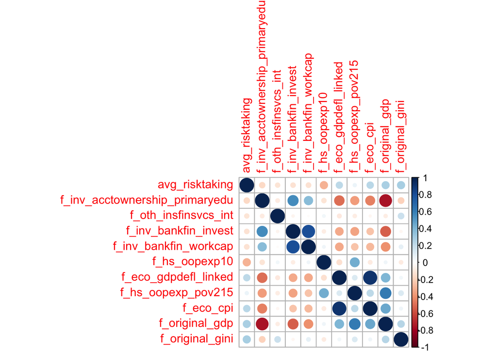

```r
library(corrplot)
numeric_vars <- hardship_Finance %>% select(where(is.numeric))
corr_matrix <- cor(numeric_vars, use = "pairwise.complete.obs")
corrplot(corr_matrix, method = "circle")
```

# Prüfung auf den Mechanismus des Fehlens von Daten

```r
# Laden des Pakets
library(mice)
```

```r
# Fehlende Werte berechnen
missing_percentages <- sapply(hardship_Finance, function(x) {
  sum(is.na(x)) / length(x) * 100
})

# Ergebnisse in DataFrame umwandeln
missing_summary <- data.frame(
  Variable = names(missing_percentages),
  MissingPercentage = missing_percentages
)

# Nach Prozent sortieren
missing_summary <- missing_summary[order(-missing_summary$MissingPercentage), ]

# Ausgabe der Tabelle
print(missing_summary)
```

```
##                                                      Variable MissingPercentage
## f_hs_oopexp_pov215                         f_hs_oopexp_pov215        25.0000000
## f_inv_bankfin_invest                     f_inv_bankfin_invest        23.0769231
## f_inv_bankfin_workcap                   f_inv_bankfin_workcap        23.0769231
## f_hs_oopexp10                                   f_hs_oopexp10        17.3076923
## f_oth_insfinsvcs_int                     f_oth_insfinsvcs_int         4.8076923
## f_inv_acctownership_primaryedu f_inv_acctownership_primaryedu         3.8461538
## f_eco_cpi                                           f_eco_cpi         1.9230769
## country                                               country         0.9615385
## avg_risktaking                                 avg_risktaking         0.9615385
## COUNTRY                                               COUNTRY         0.0000000
## f_eco_gdpdefl_linked                     f_eco_gdpdefl_linked         0.0000000
## f_original_gdp                                 f_original_gdp         0.0000000
## f_original_gini                               f_original_gini         0.0000000
```

```r
# Installieren des naniar Pakets, falls noch nicht geschehen
if (!require("naniar")) install.packages("naniar")

# Laden des Pakets
library(naniar)

# Durchführung von Little's MCAR-Test (ähnlich)
mcar_test <- naniar::mcar_test(hardship_Finance)

# Ausgabe des Testergebnisses
print(mcar_test)
```

```
## # A tibble: 1 × 4
##   statistic    df    p.value missing.patterns
##       <dbl> <dbl>      <dbl>            <int>
## 1      235.   146 0.00000461               16
```

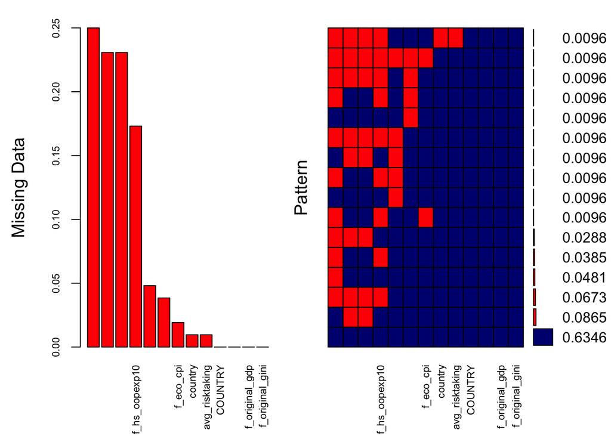

```
##
##  Variables sorted by number of missings:
##                        Variable       Count
##              f_hs_oopexp_pov215 0.250000000
##            f_inv_bankfin_invest 0.230769231
##           f_inv_bankfin_workcap 0.230769231
##                   f_hs_oopexp10 0.173076923
##            f_oth_insfinsvcs_int 0.048076923
##  f_inv_acctownership_primaryedu 0.038461538
##                       f_eco_cpi 0.019230769
##                         country 0.009615385
##                  avg_risktaking 0.009615385
##                         COUNTRY 0.000000000
##            f_eco_gdpdefl_linked 0.000000000
##                  f_original_gdp 0.000000000
##                 f_original_gini 0.000000000
```

```r
library(VIM)

# Aggregierte Missingness-Visualisierung
aggr_plot <- aggr(hardship_Finance, col = c('navyblue', 'red'), numbers = TRUE, sortVars = TRUE,
                  labels = names(hardship_Finance), cex.axis = 0.7, gap = 3, ylab = c("Missing Data", "Pattern"))
```

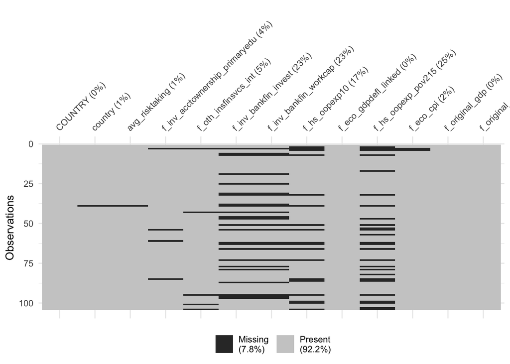

```r
vis_miss(hardship_Finance)
```

```r
# Fehlende Werte berechnen
missing_percentages <- sapply(hardship_Finance, function(x) {
  sum(is.na(x)) / length(x) * 100
})

# Ergebnisse in DataFrame umwandeln
missing_summary <- data.frame(
  Variable = names(missing_percentages),
  MissingPercentage = missing_percentages
)

# Nach Prozent sortieren
missing_summary <- missing_summary[order(-missing_summary$MissingPercentage), ]

# Ausgabe der Tabelle
print(missing_summary)
```

```
##                                                      Variable MissingPercentage
## f_hs_oopexp_pov215                         f_hs_oopexp_pov215        25.0000000
## f_inv_bankfin_invest                     f_inv_bankfin_invest        23.0769231
## f_inv_bankfin_workcap                   f_inv_bankfin_workcap        23.0769231
## f_hs_oopexp10                                   f_hs_oopexp10        17.3076923
## f_oth_insfinsvcs_int                     f_oth_insfinsvcs_int         4.8076923
## f_inv_acctownership_primaryedu f_inv_acctownership_primaryedu         3.8461538
## f_eco_cpi                                           f_eco_cpi         1.9230769
## country                                               country         0.9615385
## avg_risktaking                                 avg_risktaking         0.9615385
## COUNTRY                                               COUNTRY         0.0000000
## f_eco_gdpdefl_linked                     f_eco_gdpdefl_linked         0.0000000
## f_original_gdp                                 f_original_gdp         0.0000000
## f_original_gini                               f_original_gini         0.0000000
```

```r
# Überprüfe, ob alle Variablen tatsächlich numerisch sind
sapply(hardship_Finance, function(x) all(is.numeric(x)))
```

```
##                        COUNTRY                        country
##                          FALSE                          FALSE
##                 avg_risktaking f_inv_acctownership_primaryedu
##                           TRUE                           TRUE
##           f_oth_insfinsvcs_int           f_inv_bankfin_invest
##                           TRUE                           TRUE
##          f_inv_bankfin_workcap                  f_hs_oopexp10
##                           TRUE                           TRUE
##           f_eco_gdpdefl_linked             f_hs_oopexp_pov215
##                           TRUE                           TRUE
##                      f_eco_cpi                 f_original_gdp
##                           TRUE                           TRUE
##                f_original_gini
##                           TRUE
```

```r
# Erstelle einen Methoden-Vektor
methods <- rep("none", ncol(hardship_Finance))
names(methods) <- colnames(hardship_Finance)

# Weisen den relevanten Spalten Imputationsmethoden zu
methods["f_original_gini"] <- "pmm"           # Numerisch
methods["f_original_gdp"] <- "pmm"                     # Numerisch
methods["femalemale_primedu"] <- "pmm"       # Numerisch
methods["f_inv_acctownership_primaryedu"] <- "pmm"           # Numerisch
methods["f_oth_insfinsvcs_int"] <- "pmm"   # Numerisch
methods["f_hs_oopexp10"] <- "pmm"              # Numerisch
methods["f_eco_gdpdefl_linked"] <- "pmm"           # Numerisch
methods["f_bofp_netfinacct"] <- "pmm"           # Numerisch
methods["f_inv_bankfin_invest"] <- "pmm"           # Numerisch
methods["f_inv_bankfin_workcap"] <- "pmm"           # Numerisch
```

```r
library(mice)

# Auswahl nur der numerischen Spalten
hardship_Finance_numeric <- hardship_Finance %>%
  select(where(is.numeric)) %>%
  select(-avg_risktaking)

# Entfernen von f_hs_oopexp10
hardship_Finance <- hardship_Finance %>% select(-f_inv_bankfin_invest)
hardship_Finance <- hardship_Finance %>% select(-f_inv_bankfin_workcap)
hardship_Finance <- hardship_Finance %>% select(-f_hs_oopexp_pov215)

# Erneute Imputation durchführen
imputed_data <- mice(
  hardship_Finance_numeric,
  m = 20,
  maxit = 50,
  method = "pmm",
  seed = 123
)
completed_data <- complete(imputed_data, 1)

# Zusammenfassung der Imputationsergebnisse
summary(imputed_data)
```

```
## Class: mids
## Number of multiple imputations:  20
## Imputation methods:
## f_inv_acctownership_primaryedu           f_oth_insfinsvcs_int
##                          "pmm"                          "pmm"
##           f_inv_bankfin_invest          f_inv_bankfin_workcap
##                          "pmm"                          "pmm"
##                  f_hs_oopexp10           f_eco_gdpdefl_linked
##                          "pmm"                             ""
##             f_hs_oopexp_pov215                      f_eco_cpi
##                          "pmm"                          "pmm"
##                 f_original_gdp                f_original_gini
##                             ""                             ""
## PredictorMatrix:
##                                f_inv_acctownership_primaryedu
## f_inv_acctownership_primaryedu                              0
## f_oth_insfinsvcs_int                                        1
## f_inv_bankfin_invest                                        1
## f_inv_bankfin_workcap                                       1
## f_hs_oopexp10                                               1
## f_eco_gdpdefl_linked                                        1
##                                f_oth_insfinsvcs_int f_inv_bankfin_invest
## f_inv_acctownership_primaryedu                    1                    1
## f_oth_insfinsvcs_int                              0                    1
## f_inv_bankfin_invest                              1                    0
## f_inv_bankfin_workcap                             1                    1
## f_hs_oopexp10                                     1                    1
## f_eco_gdpdefl_linked                              1                    1
##                                f_inv_bankfin_workcap f_hs_oopexp10
## f_inv_acctownership_primaryedu                     1             1
## f_oth_insfinsvcs_int                               1             1
## f_inv_bankfin_invest                               1             1
## f_inv_bankfin_workcap                              0             1
## f_hs_oopexp10                                      1             0
## f_eco_gdpdefl_linked                               1             1
##                                f_eco_gdpdefl_linked f_hs_oopexp_pov215
## f_inv_acctownership_primaryedu                    1                  1
## f_oth_insfinsvcs_int                              1                  1
## f_inv_bankfin_invest                              1                  1
## f_inv_bankfin_workcap                             1                  1
## f_hs_oopexp10                                     1                  1
## f_eco_gdpdefl_linked                              0                  1
##                                f_eco_cpi f_original_gdp f_original_gini
## f_inv_acctownership_primaryedu         1              1               1
## f_oth_insfinsvcs_int                   1              1               1
## f_inv_bankfin_invest                   1              1               1
## f_inv_bankfin_workcap                  1              1               1
## f_hs_oopexp10                          1              1               1
## f_eco_gdpdefl_linked                   1              1               1
```

```r
# Zugriff auf den ersten vollständig imputierten Datensatz
completed_data <- complete(imputed_data, 1)

# Überprüfung der Struktur des vollständigen Datensatzes
str(completed_data)
```

```
## 'data.frame':    104 obs. of  10 variables:
##  $ f_inv_acctownership_primaryedu: num  5.08 39.21 95.65 40.27 6.55 ...
##  $ f_oth_insfinsvcs_int          : num  2.67 2.72 4.24 3.89 4.86 ...
##  $ f_inv_bankfin_invest          : num  1.7 8.9 48.6 18.6 32.9 ...
##  $ f_inv_bankfin_workcap         : num  3.2 28.6 27.9 31 44.6 ...
##  $ f_hs_oopexp10                 : num  9.73 11.63 1.53 3.21 12.89 ...
##  $ f_eco_gdpdefl_linked          : num  7.37 8.08 1.36 20.87 4.37 ...
##  $ f_hs_oopexp_pov215            : num  2.385 0.00778 0 0.01 0.273 ...
##  $ f_eco_cpi                     : num  8.02 4.15 1.18 19.66 4.75 ...
##  $ f_original_gdp                : num  2.236 0.349 -1.084 -0.286 0.107 ...
##  $ f_original_gini               : num  -0.996 -1.222 -1.272 0.627 -1.524 ...
```

```r
imputed_data$imp$f_inv_acctownership_primaryedu  # Zeigt die imputierten Werte für diese Variable
```

```
##        1      2      3      4      5      6      7       8      9     10     11
## 3  95.65 94.705 98.155 92.650 95.650 91.050 95.650 100.000 87.410 92.650 43.740
## 54  6.89 40.270 22.980 19.495 16.365 23.145 17.080   9.575  9.575 23.145  7.165
## 61  3.10  9.295 21.715  6.890  6.890 77.915 35.025  13.000 17.080 22.980 35.025
## 85 40.27 77.915 30.550 21.715 17.685 42.610  3.100  21.715 30.720 29.595 25.000
##        12    13     14     15     16     17     18     19     20
## 3  86.000 91.05 98.155 99.595 86.000 92.530 87.410 42.695 94.945
## 54 64.775 17.08 42.610 42.610  6.890  9.925 16.365 27.585 12.985
## 61  6.890 17.08 19.495  6.550 12.985 42.610 23.880 12.985 27.585
## 85 77.915 13.00  6.550 21.915 28.915 35.025 57.845 64.775 21.915
```

```r
imputed_data$imp$f_oth_insfinsvcs_int  # Zeigt die imputierten Werte für diese Variable
```

```
##            1        2        3        4        5        6        7         8
## 3   4.241413 2.715435 1.793377 5.065008 7.914229 3.888502 4.160514  2.665690
## 43  4.877684 3.396936 5.193207 8.081334 8.081334 7.881296 3.943080  5.564176
## 95  5.550799 2.318789 8.861865 9.020489 8.575866 6.130735 5.193207  8.433136
## 101 7.533924 8.437640 2.831420 6.039942 7.881296 6.039942 5.296742 15.614440
## 104 3.384045 3.917732 3.396936 5.564176 5.193207 3.620183 4.308344 23.668474
##            9        10        11        12         13       14        15
## 3   3.212005  8.437640 11.534451  9.020489 13.0079150 6.865995  6.130735
## 43  3.145737  3.805931  5.495275  2.318789  3.6201835 6.130735  1.793377
## 95  8.023369 15.614440  3.753013  6.511088  0.5490286 3.384045  8.081334
## 101 8.023369  2.506975  6.588777  2.810446  4.8591344 9.239697 15.614440
## 104 6.865995  4.160514  5.550799 13.007915  6.4639593 6.969405  3.888502
##           16       17       18       19       20
## 3   3.212005 8.575866 2.665690 6.124249 8.906279
## 43  8.081334 6.304419 2.627710 2.506975 8.861865
## 95  3.805931 3.212005 8.218533 6.463959 9.020489
## 101 9.050639 7.881296 5.065008 5.296742 7.533924
## 104 6.511088 3.145737 5.296742 6.304419 2.665690
```

```r
imputed_data$imp$f_hs_oopexp10  # Zeigt die imputierten Werte für diese Variable
```

```
##            1        2         3         4         5         6         7
## 2   11.63333 11.84800 11.789000  5.006667  3.210000  5.006667  1.880000
## 3    1.53000 11.84800 19.300000 15.416000 12.850000 17.700000 11.789000
## 4    3.21000 10.27000  2.900000  7.544000  4.016000  2.295000  4.130000
## 7    1.78500  2.00500  2.460000 14.340000 17.603333  9.160000 14.640000
## 32  11.78900  9.73500  4.452000  2.900000  1.100000 13.913000  6.700000
## 39  14.64000 11.78900 16.050000 11.633333 11.789000 18.380000  3.780000
## 51  13.91300 17.60333 11.789000  5.550000 12.850000  8.120000 18.380000
## 54   3.77000 13.91300  3.495000  1.903333 12.891000 14.340000 11.313333
## 62   9.29000 16.05000  1.730000 10.270000 10.750000 10.853750 13.913000
## 63   3.78000 20.01000  1.903333  8.165000  4.130000  5.550000  3.796667
## 66   1.78500 20.17333  1.880000  9.290000 11.313333  1.530000  8.165000
## 73  17.60333 17.70000 13.280000 15.965000 20.455000 10.853750 17.603333
## 85   4.09400  2.90000 15.416000  3.230000 10.485000  5.723333 14.340000
## 86   1.78500  1.78500 11.313333  1.785000 19.300000 10.750000  3.780000
```

[output cut: 42 more lines]

```r
imputed_data$imp$f_eco_gdpdefl_linked  # Zeigt die imputierten Werte für diese Variable
```

```
##  [1] 1  2  3  4  5  6  7  8  9  10 11 12 13 14 15 16 17 18 19 20
## <0 rows> (or 0-length row.names)
```

```r
imputed_data$imp$f_eco_cpi  # Zeigt die imputierten Werte für diese Variable
```

```
##           1         2         3         4         5         6         7
## 3  1.175173  2.668954  2.322359  2.322359  4.509729  2.880934  3.015801
## 4 19.660127 13.139803 14.185257 13.139803 14.185257 17.170386 13.139803
##           8         9         10        11        12        13       14
## 3  1.175173  1.650676  0.4905884  2.531387  2.322359  2.322359  2.29082
## 4 14.185257 13.139803 12.0282686 13.139803 12.028269 19.660127 12.02827
##         15        16        17        18         19        20
## 3  2.29082  1.763463  2.322359  1.175173  0.4905884  2.215828
## 4 12.02827 14.185257 12.028269 13.139803 17.1703861 14.185257
```

```r
imputed_data$imp$f_original_gdp
```

```
##  [1] 1  2  3  4  5  6  7  8  9  10 11 12 13 14 15 16 17 18 19 20
## <0 rows> (or 0-length row.names)
```

```r
imputed_data$imp$f_original_gini
```

```
##  [1] 1  2  3  4  5  6  7  8  9  10 11 12 13 14 15 16 17 18 19 20
## <0 rows> (or 0-length row.names)
```

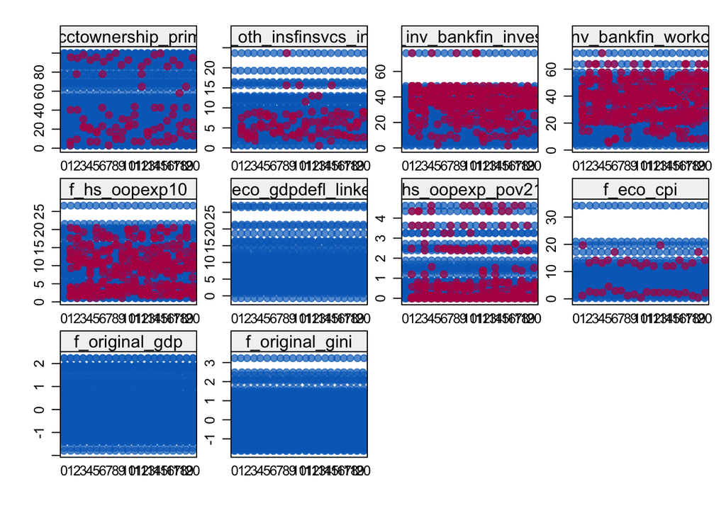

```r
# visualisierung
stripplot(imputed_data, pch = 20, cex = 1.2)  # Verteilung der imputierten Werte
```

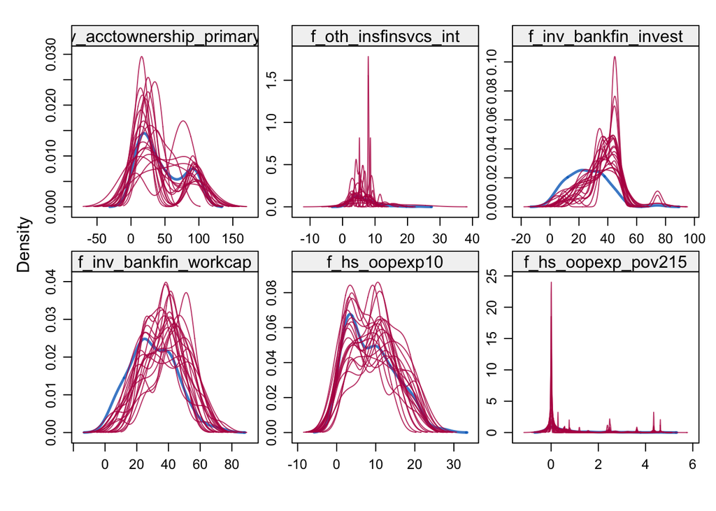

```r
densityplot(imputed_data)  # Dichte der imputierten Werte
```

```r
# Imputierte Daten extrahieren
completed_data <- complete(imputed_data, action = 1)
```

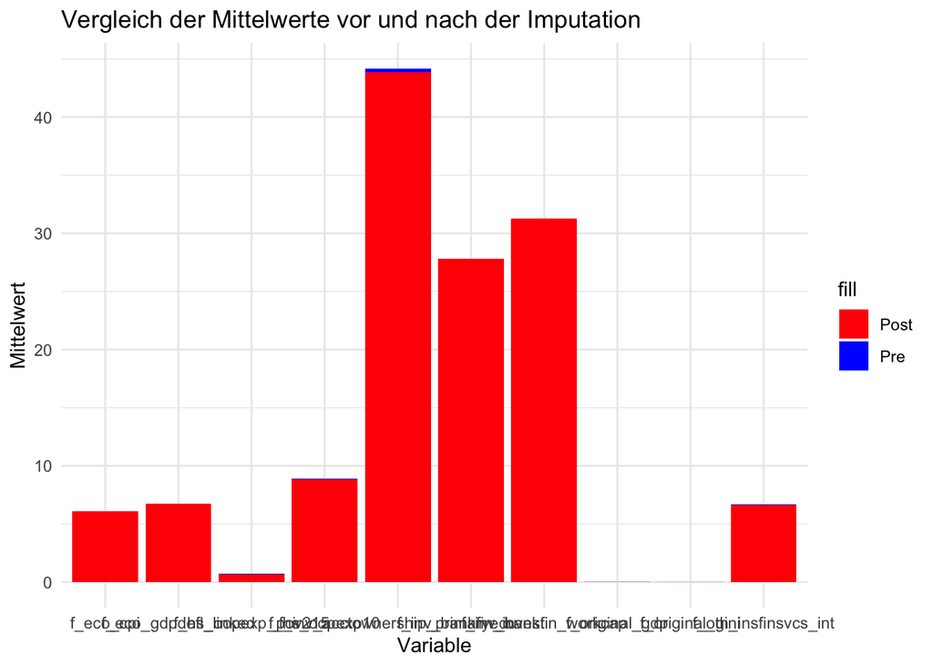

```r
# Berechnen der Mittelwerte vor der Imputation
mean_values_pre_imputation <- sapply(hardship_Finance_numeric, mean, na.rm = TRUE)

# Berechnen der Mittelwerte nach der Imputation
mean_values_post_imputation <- sapply(completed_data, mean, na.rm = TRUE)

# Erhalten der Schnittmenge der Namen von Variablen in beiden Datensätzen
common_vars <- intersect(names(mean_values_pre_imputation), names(mean_values_post_imputation))

# Anpassen der Mittelwertdatensätze, um nur gemeinsame Variablen zu enthalten
mean_values_pre_imputation <- mean_values_pre_imputation[common_vars]
mean_values_post_imputation <- mean_values_post_imputation[common_vars]

# Erstellen des Vergleichsdatensatzes
comparison_data <- data.frame(
  Variable = common_vars,
  PreImputation = mean_values_pre_imputation,
  PostImputation = mean_values_post_imputation
)

library(ggplot2)
ggplot(comparison_data, aes(x = Variable, y = PreImputation, fill = "Pre")) +
  geom_bar(stat = "identity", position = "dodge") +
  geom_bar(aes(y = PostImputation, fill = "Post"), stat = "identity", position = "dodge") +
  theme_minimal() +
  labs(title = "Vergleich der Mittelwerte vor und nach der Imputation", y = "Mittelwert") +
  scale_fill_manual(values = c("Pre" = "blue", "Post" = "red"))
```

# Füge die imputierten Variablen zurück in den ursprünglichen Datensatz ein:

```r
hardship_Finance <- hardship_Finance %>%
  mutate(
    f_inv_acctownership_primaryedu = completed_data$f_inv_acctownership_primaryedu,
    f_oth_insfinsvcs_int = completed_data$f_oth_insfinsvcs_int,
    f_hs_oopexp10 = completed_data$f_hs_oopexp10,
    f_eco_gdpdefl_linked = completed_data$f_eco_gdpdefl_linked,
    f_eco_cpi = completed_data$f_eco_cpi,
    f_original_gdp = completed_data$f_original_gdp,
    f_original_gini = completed_data$f_original_gini
  )

# Überprüfung der Struktur des aktualisierten Datensatzes
str(hardship_Finance)
```

```
## 'data.frame':    104 obs. of  10 variables:
##  $ COUNTRY                       : chr  "AFG" "DZA" "AND" "ARG" ...
##  $ country                       : chr  "Afghanistan" "Algeria" "Andorra" "Argentina" ...
##  $ avg_risktaking                : num  51.7 53 51.9 48.6 49 ...
##  $ f_inv_acctownership_primaryedu: num  5.08 39.21 95.65 40.27 6.55 ...
##  $ f_oth_insfinsvcs_int          : num  2.67 2.72 4.24 3.89 4.86 ...
##  $ f_hs_oopexp10                 : num  9.73 11.63 1.53 3.21 12.89 ...
##  $ f_eco_gdpdefl_linked          : num  7.37 8.08 1.36 20.87 4.37 ...
##  $ f_eco_cpi                     : num  8.02 4.15 1.18 19.66 4.75 ...
##  $ f_original_gdp                : num  2.236 0.349 -1.084 -0.286 0.107 ...
##  $ f_original_gini               : num  -0.996 -1.222 -1.272 0.627 -1.524 ...
```

```r
# Überprüfe, ob es noch fehlende Werte in den relevanten Variablen gibt
sum(is.na(hardship_Finance$f_inv_acctownership_primaryedu))  # Soll 0 ergeben
```

```
## [1] 0
```

```r
sum(is.na(hardship_Finance$f_oth_insfinsvcs_int))  # Soll 0 ergeben
```

```
## [1] 0
```

```r
sum(is.na(hardship_Finance$f_hs_oopexp10))  # Soll 0 ergeben
```

```
## [1] 0
```

```r
sum(is.na(hardship_Finance$f_eco_gdpdefl_linked))  # Soll 0 ergeben
```

```
## [1] 0
```

```r
sum(is.na(hardship_Finance$f_eco_cpi))  # Soll 0 ergeben
```

```
## [1] 0
```

## check countryfacts

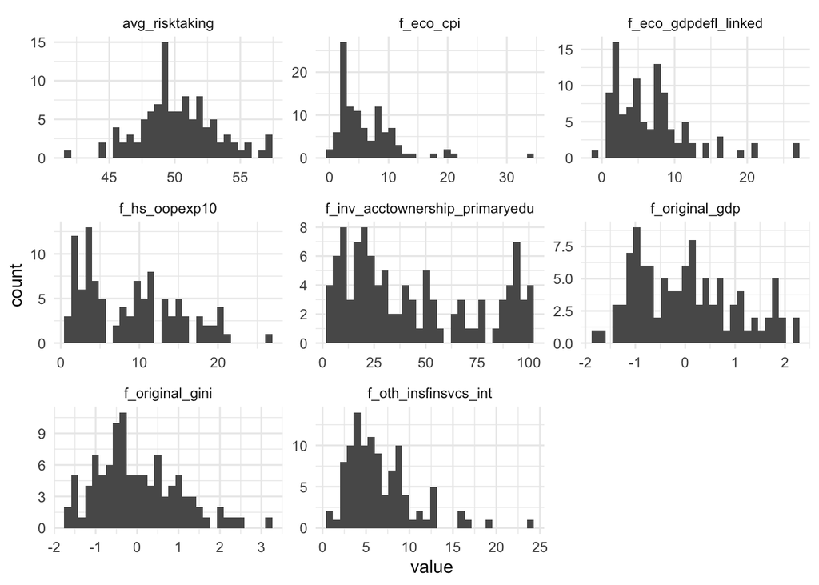

```r
# Plot histograms for each numeric variable
hardship_Finance %>%
  select_if(is.numeric) %>%
  gather() %>%
  ggplot(aes(value)) +
  facet_wrap(~key, scales = "free") +
  geom_histogram(bins = 30) +
  theme_minimal()
```

# Ausreisser

```r
# Winsorisierung nur auf Variablen mit potenziellen Ausreißern
winsorize <- function(x, lower_quantile = 0.01, upper_quantile = 0.99) {
  lower <- quantile(x, lower_quantile, na.rm = TRUE)
  upper <- quantile(x, upper_quantile, na.rm = TRUE)
  pmin(pmax(x, lower), upper)
}

hardship_Finance <- hardship_Finance %>%
  mutate(f_hs_oopexp10 = winsorize(f_hs_oopexp10)
  )

# 3. Keine Anpassung für andere Variablen (z. B. E_oth_safewater)
# Überprüfen der Struktur nach Transformationen
#view(hardship_Finance)
```

## Log Countryfacts

```r
# Log-transform the variables using dplyr
hardship_Finance <- hardship_Finance %>%
  mutate(
    f_inv_acctownership_primaryedu = log(f_inv_acctownership_primaryedu),
    f_oth_insfinsvcs_int = log(f_oth_insfinsvcs_int),
    f_hs_oopexp10 = log(f_hs_oopexp10),
    f_eco_gdpdefl_linked = log(f_eco_gdpdefl_linked),
    f_eco_cpi = log(f_eco_cpi)

  )

head(hardship_Finance)
```

```
##   COUNTRY     country avg_risktaking f_inv_acctownership_primaryedu
## 1     AFG Afghanistan       51.72412                       1.624327
## 2     DZA     Algeria       53.03729                       3.668932
## 3     AND     Andorra       51.90591                       4.560696
## 4     ARG   Argentina       48.60275                       3.695607
## 5     ARM     Armenia       48.98472                       1.879465
## 6     AUS   Australia       49.05534                       4.605170
##   f_oth_insfinsvcs_int f_hs_oopexp10 f_eco_gdpdefl_linked f_eco_cpi
## 1            0.9804629     2.2757276            1.9970463 2.0824700
## 2            0.9989523     2.4538745            2.0893129 1.4223004
## 3            1.4448965     0.4252677            0.3060937 0.1614152
## 4            1.3580241     1.1662709            3.0383729 2.9785926
## 5            1.5808603     2.5565294            1.4739283 1.5571069
## 6            1.2983727     0.8458683            1.2193267 1.0159162
##   f_original_gdp f_original_gini
## 1      2.2360657      -0.9956570
## 2      0.3486396      -1.2221060
## 3     -1.0837948      -1.2724280
## 4     -0.2861997       0.6272279
## 5      0.1067501      -1.5240381
## 6     -1.0818945      -0.3792123
```

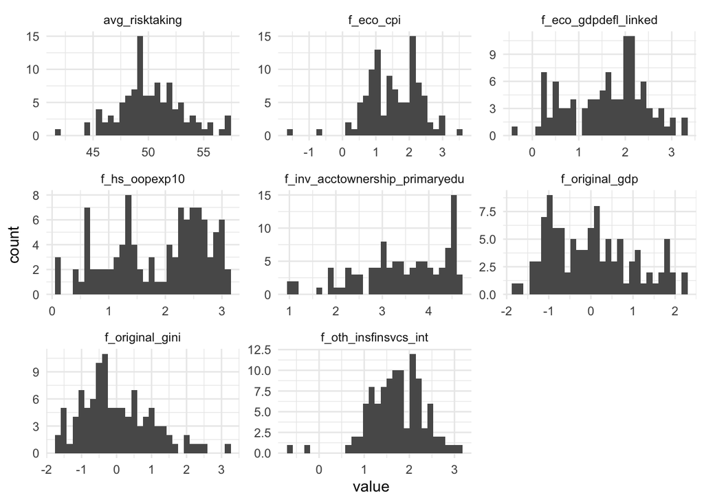

```r
# Plot histograms for each numeric variable
hardship_Finance %>%
  select_if(is.numeric) %>%
  gather() %>%
  ggplot(aes(value)) +
  facet_wrap(~key, scales = "free") +
  geom_histogram(bins = 30) +
  theme_minimal()
```